# Juvenile Snowshoe Hares in Bonanza Creek: Exploratory Report

Alia Ajina

11/3/2021

## 1. Introduction

This exploratory report provides a synopsis on juvenile snowshoe hares (*Lepus americanus*) observed at three different sites at the Bonanza Creek Experimental Forest (Long Term Ecological Research site) which is located 20 km southwest of Fairbanks, Alaska. According to the data, snowshoe hares are a ‘keystone’ prey species in boreal forests and “experience population fluctuations of 8 to 11 years,” (Kielland et al. 2017). Using data from 1998 to 2012 that was collected by Kielland et al., this report analyses annual juvenile hare count and juvenile hare weights. It also compares juvenile hare weights for both males and females and performs a linear regression on the relationship between juvenile weight and hind foot length.

## 2. Data and Analyses

Snowshoe hare physical data was collected and made accessible by Dr. Knut Kielland and his primary investigators and associates at the Bonanza Creek Long Term Ecological Research (LTER) site. The data contains observations from capture-recapture studies that were conducted in the Tanana valley from 1998 - 2012, (Kielland et al. 2017). Following exploratory data visualization, body mass measurements between male and female juvenile snowshoe hares are compared using a two-sample t-test using a significance level (α) of 0.05 throughout. Differences between groups are described by a Cohen’s d effect size. The relationship between body mass and hind foot length is explored by simple linear regression. All analyses are in R version 4.1.1 using RStudio Version 1.4.1717.

## 3. Juvenile Hare Initial Investigation

### A. Annual Juvenile Hare Trap Counts

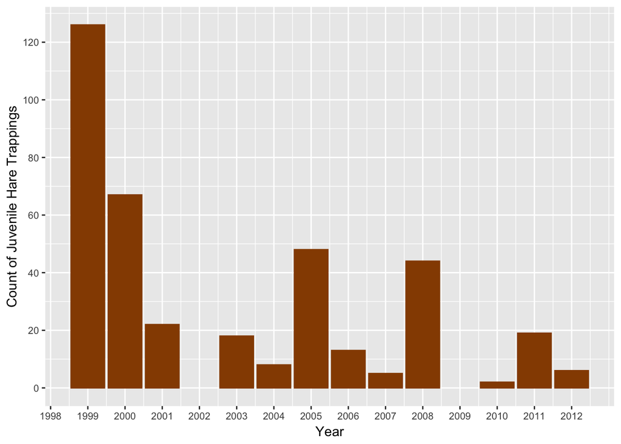

**Figure 1:** Total number of juvenile snowshoe hare trappings per year from 1998 to 2012 at Bonanza Creek Long Term Ecological Research site. Data: Kielland et al. (2017)

The minimum count for juvenile hare trappings is 2 and the maximum is 126. The mean annual number of juvenile hares trapped is 31.5 and the median is 18.5. In 1999, juvenile snowshoe hare densities were highest. It appears that since then (1999), the number of juvenile hares that have been trapped has decreased, although the trend is not profound. In years 2005 and 2008 a small increase can be seen in the number of juvenile hares trapped in comparison to years prior. There were also no juvenile hare observations in 1998, 2002, and 2009. These counts, although absolute, are impacted by effort (number of days and number of traps in the study each year). Efforts for each year may have been uniform, or they may have varied greatly, which could have affected the data collected between 1998 to 2012. It would be beneficial to the study to quantify the number of observations recorded each year and standardize that number in future analyses in order to have accurate, standardized data, that may better represent the true population of juvenile hares.

### B. Juvenile Hare Weights

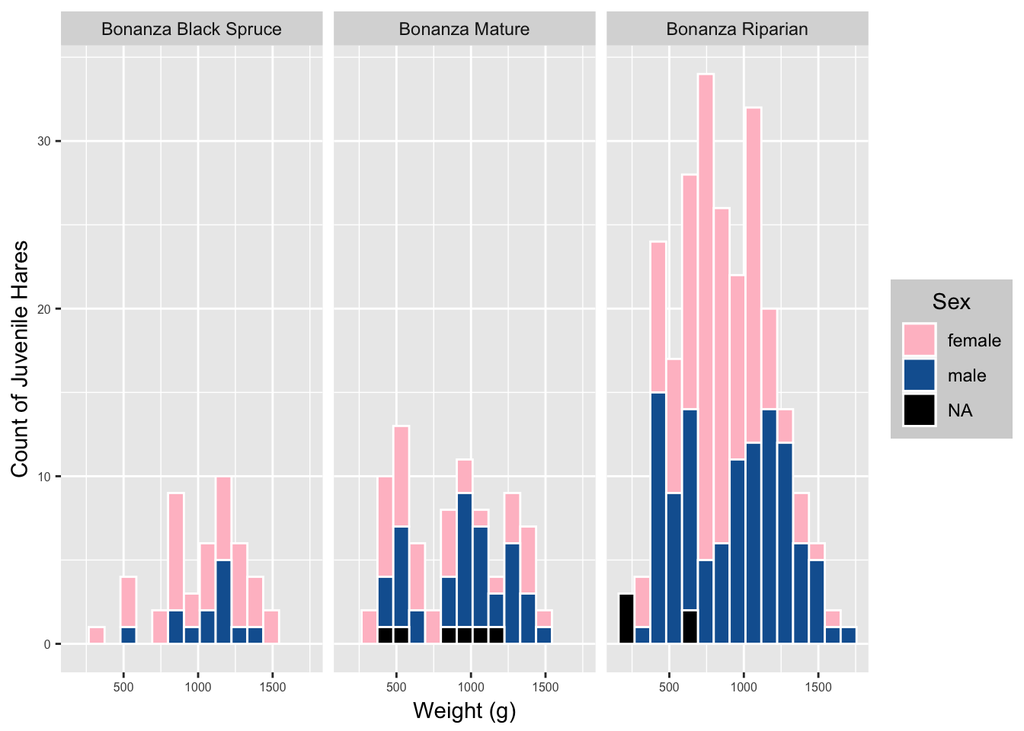

**Figure 2:** Distribution of juvenile hare weights (grams) recorded for each sex: pink (female), blue (male), black (NA), faceted at each of the three site locations (Bonanza Black Spruce, Bonanza Mature, and Bonanza Riparian) at the Bonanza Creek Long Term Ecological Research site. Data: Kielland et al. (2017)

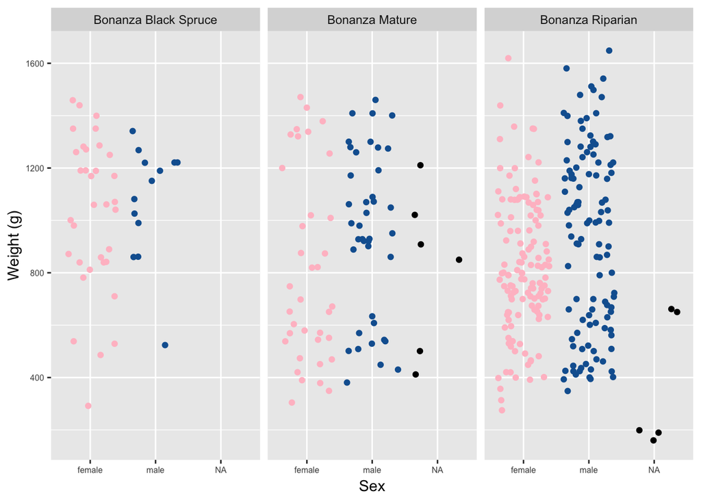

**Figure 3:** Jitter plot of the dispersion of juvenile hare weights (g) for each sex faceted by the survey site at Bonanza Creek Long Term Ecological Research site. Data: Kielland et al. (2017)

On average at each of the sites; Bonanza Black Spruce, Bonanza Mature, and Bonanza Riparian, male and female juvenile hares have similar weight distributions. The Bonanza Riparian site recorded more observations in comparison to the other sites. The distributions of weights for female hares are slightly more normal than the distribution of weights for male hares when analyzing the histogram and jitter plot seen above. However, further analysis is needed to determine if this is the case. The NA juvenile hares that are present at Bonanza Mature and Bonanza Riparian may have not been categorized by their sex due to error in data collection efforts.

### C. Juvenile Weight Comparison for Male and Female Snowshoe Hares

Table 1: Summary statistics of male and female juvenile snowshoe hare’s weight (g) at Bonanza Creek LTER. Data: Kielland et al. (2017)

| Sex | Mean Weight (g) | Median Weight (g) | Standard Deviation (g) | Sample Size |
| --- | --- | --- | --- | --- |
| Female | 855.39 | 825 | 292.25 | 200 |
| Male | 945.86 | 990 | 333.22 | 163 |
| NA | 614.55 | 650 | 357.59 | 15 |

Getting a p-value of 0.007 means there is a 0.7% chance of getting means at least as different as the ones seen here if they’re drawn from populations with the same mean. This means that we would reject the null hypothesis that the population’s mean weights are the same.

### D. Relationship between Juvenile Weight & Hind Foot Length

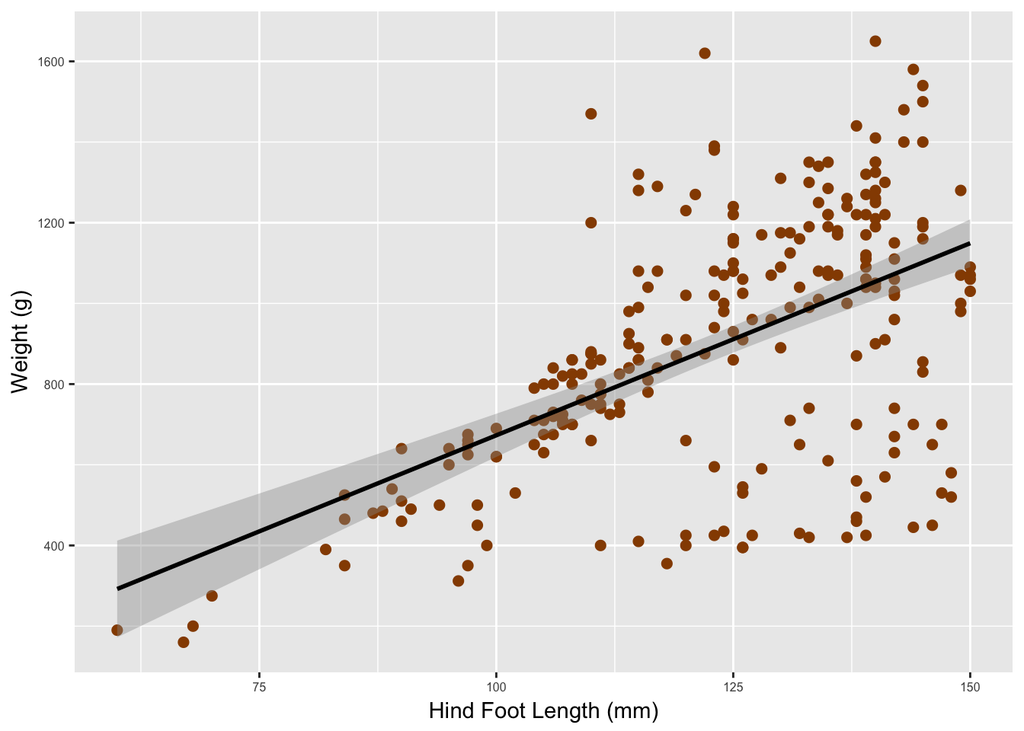

**Figure 4:** Visual relationship between all juvenile snowshoe hare’s hind foot length (mm) and weight (g). Points are individual juvenile hares. Linear model summary: $\beta$ = 9.52 g mm<sup>-1</sup>, (p < 0.001), R<sup>2</sup> = 0.3. Data: Kielland et al. (2017).

Linear regression exploration was used to further describe the relationship between juvenile snowshoe hare’s weight changes (g) with respect to hind foot length (mm) for all juvenile hares within the data set. A regression model was found $\beta$ = 9.52g mm<sup>-1</sup>, (p < 0.001), with an R<sup>2</sup> of 0.3.

Using a Pearson’s R correlation, it is shown that there is a *moderately strong*, positive correlation between juvenile hare hind foot length (mm) and body mass (g) (*r* = 0.55, p < 0.001).

Certain variables, for example, the sex of juvenile hares, is not addressed in this linear regression, which may be cause for concern as it may impact the relationship between hare weight changes and hind foot length.

## Summary:

- The second year of the study, 1999, contained the highest density of juvenile hares trapped.
- On average, female juvenile snowshoe hares are smaller than male juvenile snowshoe hares in weight. Male juvenile snowshoe hares have a mean of 945.86 and female juvenile snowhoe hares have a mean of 855.39.
- Juvenile hare weight seems to be related to hind foot length. The simple linear regression between the two has a slope of 9.52. In other words, for every 1mm increase in hind foot length, on average, it is expected that weight will increase by 9.52.

## Next Steps:

- Investigating the normality of female juvenile hare weights versus male juvenile hare weights distributions
- Adding potential predictor variables to the linear regression such as sex of juvenile hares
- Investigating all analyses for adult snowshoe hares to see if percieved relationships continue

## Citations:

Kielland, K., F.S. Chapin, R.W. Ruess, and Bonanza Creek LTER. 2017. Snowshoe hare physical data in Bonanza Creek Experimental Forest: 1998-Present ver 22. Environmental Data Initiative. https://doi.org/10.6073/pasta/03dce4856d79b91557d8e6ce2cbcdc14